# **Homework 1:**

- Please complete each of the problems below
- Show all your code to complete each question
- Provide sentence(s) explaining your solution
- For your decision tree, please be sure to output the actual image directly in python as opposed to a .dot file

It is recommended that you read chapters 3, 4, and 6 to prepare for this module!

**Please use the following dataset for problems 1 - 6**

```python
import pandas as pd

URL_adult='https://raw.githubusercontent.com/kamranbakhtiari/DESC624/main/Adult'
adult = pd.read_csv(URL_adult)

adult
```

|  | age | workclass | demogweight | education | education-num | marital-status | occupation | relationship | race | sex | capital-gain | capital-loss | hours-per-week | native-country | income |
| --- | --- | --- | --- | --- | --- | --- | --- | --- | --- | --- | --- | --- | --- | --- | --- |
| 0 | 39 | State-gov | 77516 | Bachelors | 13 | Never-married | Adm-clerical | Not-in-family | White | Male | 2174 | 0 | 40 | United-States | <=50K. |
| 1 | 50 | Self-emp-not-inc | 83311 | Bachelors | 13 | Married-civ-spouse | Exec-managerial | Husband | White | Male | 0 | 0 | 13 | United-States | <=50K. |
| 2 | 38 | Private | 215646 | HS-grad | 9 | Divorced | Handlers-cleaners | Not-in-family | White | Male | 0 | 0 | 40 | United-States | <=50K. |
| 3 | 53 | Private | 234721 | 11th | 7 | Married-civ-spouse | Handlers-cleaners | Husband | Black | Male | 0 | 0 | 40 | United-States | <=50K. |
| 4 | 28 | Private | 338409 | Bachelors | 13 | Married-civ-spouse | Prof-specialty | Wife | Black | Female | 0 | 0 | 40 | Cuba | <=50K. |
| ... | ... | ... | ... | ... | ... | ... | ... | ... | ... | ... | ... | ... | ... | ... | ... |
| 24995 | 41 | Private | 112507 | 10th | 6 | Married-civ-spouse | Transport-moving | Husband | White | Male | 0 | 0 | 60 | United-States | <=50K. |
| 24996 | 19 | Private | 236940 | HS-grad | 9 | Never-married | Farming-fishing | Own-child | White | Male | 0 | 0 | 40 | United-States | <=50K. |
| 24997 | 33 | Private | 278514 | HS-grad | 9 | Divorced | Craft-repair | Own-child | White | Female | 0 | 0 | 42 | United-States | <=50K. |
| 24998 | 21 | ? | 433330 | Some-college | 10 | Never-married | ? | Unmarried | White | Male | 0 | 0 | 40 | United-States | <=50K. |
| 24999 | 25 | Private | 258379 | Bachelors | 13 | Married-civ-spouse | Prof-specialty | Wife | White | Female | 0 | 0 | 32 | United-States | <=50K. |

25000 rows × 15 columns

**1. Partition the data set, so that 50% of the records are included in the training data set and 50% are included in the test data set. Use a bar graph to conifrm your proportions**

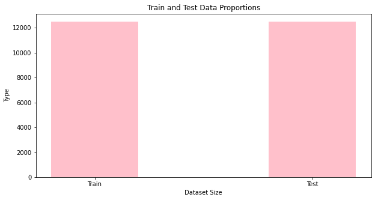

```python
### Show your Code Here ###
from sklearn.model_selection import train_test_split

import numpy as np
import matplotlib.pyplot as plt

x_train,x_test = train_test_split(adult,test_size=0.5)

data = {"Train": len(x_train), "Test": len(x_test)}

data_name = list(data.keys())
data_len = list(data.values())

fig = plt.figure(figsize = (10, 5))

# creating the bar plot
plt.bar(data_name, data_len, color ='pink',width = 0.4)

plt.xlabel("Dataset Size")
plt.ylabel("Type")
plt.title("Train and Test Data Proportions")
plt.show()
```

Solving this problem splitting the dataset by finding the length of the splits. The lengths are then fitted into a bar plot to show their equality.

**2. Identify the total number of records in the training data set, and how many records in the training data set have an income value of < 50k**

```python
### Show your Code Here ###

print("The training dataset has", len(x_train),"samples", "\n")

income_less50k = x_train[(x_train["income"] == "<=50K.")]

print("There are",len(income_less50k), "samples below the 50K mark.", "\n")
```

```
The training dataset has 12500 samples

There are 9524 samples below the 50K mark.
```

**3. Use your answers from the previous excercise to calculate how many records with income >50k you need to resmaple in order to have 35% of the rebalanced data set have incomes of >50k**

```python
### Show your Code Here ###
income_above50k = x_train[(x_train["income"] == ">50K.")]

print("There are",len(income_above50k), "samples above the 50K mark.", "\n")

print("This sample currently stands at: ", len(income_above50k)/12500*100, "% out of the possible 100%", "\n")

print("Thus to attain 35% i will need to sample", 35/100*12500, "samples")
```

```
There are 2976 samples above the 50K mark.

This sample currently stands at:  23.808 % out of the possible 100%

Thus to attain 35% i will need to sample 4375.0 samples
```

```python
### Show your Code Here ###
```

**5. Validate your partition by performing a two-sample Z-test for the difference in means for the mean age in the training set versus the mean age in the test set?**

```python
from statsmodels.stats.weightstats import ztest as ztest

alpha  = 0.05

z_stat, p_value = ztest(x_train["age"], x_test["age"], value=0)

print("The Z-statistic is", z_stat, "while the p_value is", p_value, "\n")

if(p_value < alpha):
  print("Since the p-value",p_value,"is less than 0.05, we have sufficient evidence to reject the null hypothesis.")
else:
  print("Since the p-value",p_value,"is not less than 0.05, we do not have sufficient evidence to reject the null hypothesis.")
```

```
The Z-statistic is -1.147299469824606 while the p_value is 0.2512578730691105

Since the p-value 0.2512578730691105 is not less than 0.05, we do not have sufficient evidence to reject the null hypothesis.
```

**6. Validate your partition by performing a two-sample Z-test for the difference in proportion of >50k records in the training set versus the proportion of >50k records in the test set?**

```python
from sklearn.preprocessing import LabelEncoder

le = LabelEncoder()

a = le.fit_transform(x_train["income"])
d = le.fit_transform(x_test["income"])


alpha  = 0.05

z_stat, p_value = ztest(a, d, value=0)

print("The z-statistic is", z_stat, "while the p_value is", p_value, "\n")

if(p_value < alpha):
  print("Since the p-value",p_value,"is less than 0.05, we have sufficient evidence to reject the null hypothesis.")
else:
  print("Since the p-value",p_value,"is not less than 0.05, we do not have sufficient evidence to reject the null hypothesis.")
```

```
The z-statistic is -0.4742957001789299 while the p_value is 0.6352890573085628

Since the p-value 0.6352890573085628 is not less than 0.05, we do not have sufficient evidence to reject the null hypothesis.
```

**Please use the following dataset for problems 7 - 8**

```python
import pandas as pd

URL_loan_training='https://raw.githubusercontent.com/kamranbakhtiari/DESC624/main/Loans_Training'
URL_loan_test='https://raw.githubusercontent.com/kamranbakhtiari/DESC624/main/Loans_Test'

loan_test = pd.read_csv(URL_loan_test)
loan_training = pd.read_csv(URL_loan_training)

loan_test
loan_training
```

|  | Approval | Debt-to-Income Ratio | FICO Score | Request Amount | Interest |
| --- | --- | --- | --- | --- | --- |
| 0 | F | 0.00 | 397 | 1000 | 450.0 |
| 1 | F | 0.00 | 403 | 500 | 225.0 |
| 2 | F | 0.00 | 408 | 1000 | 450.0 |
| 3 | F | 0.00 | 408 | 2000 | 900.0 |
| 4 | F | 0.00 | 411 | 5000 | 2250.0 |
| ... | ... | ... | ... | ... | ... |
| 150297 | T | 0.38 | 709 | 19000 | 8550.0 |
| 150298 | T | 0.38 | 722 | 17000 | 7650.0 |
| 150299 | T | 0.38 | 747 | 11000 | 4950.0 |
| 150300 | T | 0.39 | 679 | 10000 | 4500.0 |
| 150301 | T | 0.39 | 769 | 7000 | 3150.0 |

150302 rows × 5 columns

**7. Create a CART model using the training data set that predicts Approval using Debt to Income Ratio, FICO score, and Request Amount. Visualize the decision Tree (make sure the decision tree appears directly in this workbook, not a seperate .dot file). Describe the first few splits in the decision tree. What do the values in the brackets represent? The sample size for each node? the Root?**

```python
### Show your Code Here ###
y_train, y_test = loan_training.pop("Approval"), loan_test.pop("Approval")


loan_training.pop("Interest")
loan_test.pop("Interest")
```

```
0         900.0
1         450.0
2        2700.0
3         450.0
4         450.0
          ...
49693    6300.0
49694    7200.0
49695    1800.0
49696    2700.0
49697     225.0
Name: Interest, Length: 49698, dtype: float64
```

```python
from sklearn.tree import DecisionTreeClassifier
from sklearn.model_selection import cross_val_score

max_depth = 3

approval_train_encoded = le.fit_transform(y_train)

model=DecisionTreeClassifier(criterion='gini', max_depth=max_depth)

model.fit(loan_training, approval_train_encoded)

cross_val_score(model, loan_training, approval_train_encoded, cv=10)
```

```
array([0.4994345 , 0.80373894, 0.8338656 , 0.81842981, 0.8241517 ,
       0.7996008 , 0.76074518, 0.72441783, 0.51071191, 0.55848303])
```

```python
model.score(loan_training, approval_train_encoded)
```

```
0.8458769677050205
```

```python
model.get_depth()
```

```
3
```

```python
model.get_n_leaves()
```

```
8
```

```python
model.cost_complexity_pruning_path(loan_training, approval_train_encoded)
```

```
{'ccp_alphas': array([0.        , 0.00126397, 0.00176216, 0.01035131, 0.0127613 ,
        0.01500996, 0.10583663, 0.32272146]),
 'impurities': array([0.53029229, 0.53155626, 0.53331842, 0.54366973, 0.55643102,
        0.57144099, 0.67727761, 0.99999908])}
```

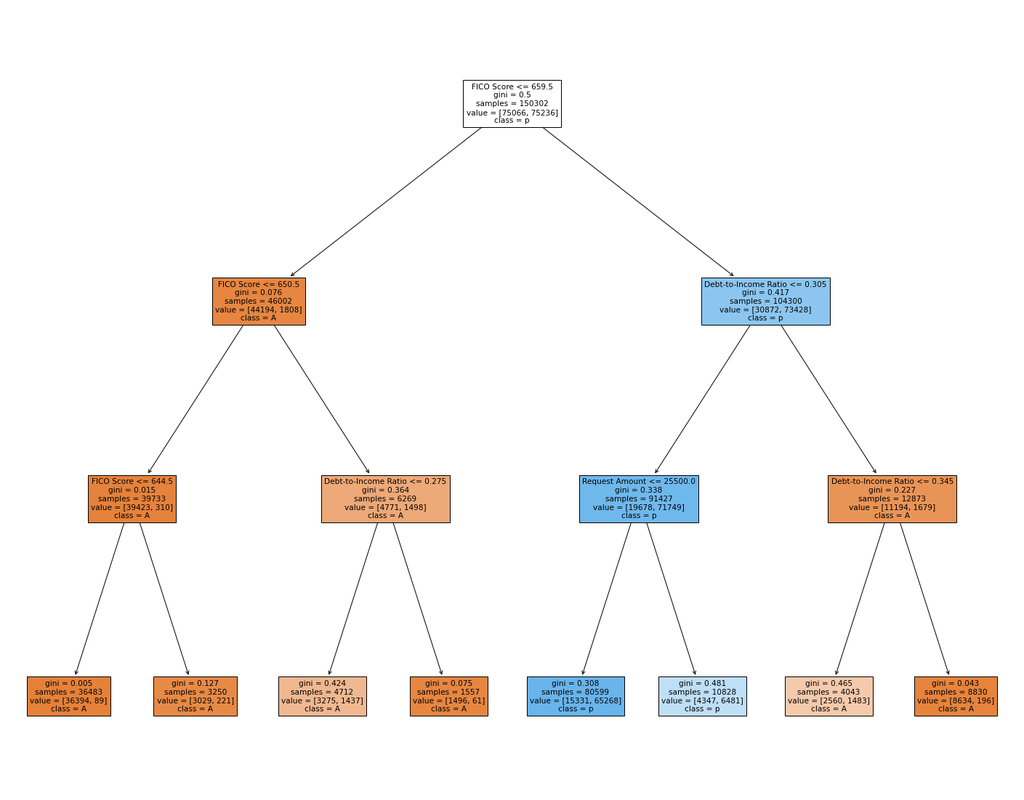

```python
from sklearn import tree
from matplotlib import pyplot as plt

feature_names = loan_training.columns.to_list()
target_names = "Approval"

fig = plt.figure(figsize=(25,20))
_ = tree.plot_tree(model, feature_names = feature_names, class_names = target_names, filled=True)
```

**8. Create a CART model using the test data set that uses the same target and predictor variables. Visualize the decision Tree (make sure the decision tree appears directly in this workbook, not a seperate .dot file). Describe the first few splits in the decision tree. What do the values in the brackets represent? The sample size for each node? the Root? Does the tree built using the test data match the tree built using the training data?**

```python
max_depth = 3

approval_test_encoded = le.fit_transform(y_test)

model=DecisionTreeClassifier(criterion='gini', max_depth=max_depth)

model.fit(loan_test, approval_test_encoded)

cross_val_score(model, loan_test, approval_test_encoded, cv=10)
```

```
array([0.50181087, 0.80744467, 0.8360161 , 0.80704225, 0.80865191,
       0.80321932, 0.76056338, 0.7193159 , 0.52686657, 0.56429865])
```

```python
model.score(loan_test, approval_test_encoded)
```

```
0.8438166525815928
```

```python
model.cost_complexity_pruning_path(loan_test, approval_test_encoded)
```

```
{'ccp_alphas': array([0.        , 0.00107421, 0.001802  , 0.00495365, 0.01335473,
        0.01994907, 0.10530435, 0.3170556 ]),
 'impurities': array([0.53649794, 0.53757215, 0.53937415, 0.5443278 , 0.55768253,
        0.5776316 , 0.68293596, 0.99999156])}
```

```python
model.get_n_leaves()
```

```
8
```

[figure not shown]

```python
from sklearn import tree
from matplotlib import pyplot as plt

feature_names = loan_test.columns.to_list()
target_names = "Approval"

fig = plt.figure(figsize=(25,20))
_ = tree.plot_tree(model, feature_names = feature_names, class_names = target_names, filled=True)
```